# MSDS 6303 Week 4 HW

Quincy Roundtree

6/6/2018

# Install the fivethirtyeight package.

```r
install.packages("fivethirtyeight", repos = "http://cran.us.r-project.org")
```

# In the listing of Data sets in package ‘fivethirtyeight,’ assign the eighteenth data set to an object ‘df.’

```r
df <- fivethirtyeight::college_all_ages
```

# Use a more detailed list of the data sets to write out the URL in a comment to the related news story.

```r
data(package = "fivethirtyeight")
```

# https://fivethirtyeight.com/features/the-economic-guide-to-picking-a-college-major/

# Using R command(s), give the dimensions and column names of this data frame.

```r
    head(df)
```

```
##   major_code                                 major
## 1       1100                   General Agriculture
## 2       1101 Agriculture Production And Management
## 3       1102                Agricultural Economics
## 4       1103                       Animal Sciences
## 5       1104                          Food Science
## 6       1105            Plant Science And Agronomy
##                    major_category  total employed
## 1 Agriculture & Natural Resources 128148    90245
## 2 Agriculture & Natural Resources  95326    76865
## 3 Agriculture & Natural Resources  33955    26321
## 4 Agriculture & Natural Resources 103549    81177
## 5 Agriculture & Natural Resources  24280    17281
## 6 Agriculture & Natural Resources  79409    63043
##   employed_fulltime_yearround unemployed unemployment_rate p25th median
## 1                       74078       2423        0.02614711 34000  50000
## 2                       64240       2266        0.02863606 36000  54000
## 3                       22810        821        0.03024832 40000  63000
## 4                       64937       3619        0.04267890 30000  46000
## 5                       12722        894        0.04918845 38500  62000
## 6                       51077       2070        0.03179089 35000  50000
##   p75th
## 1 80000
## 2 80000
## 3 98000
## 4 72000
## 5 90000
## 6 75000
```

```r
    dim(df)
```

```
## [1] 173  11
```

```r
    colnames(df)
```

```
##  [1] "major_code"                  "major"
##  [3] "major_category"              "total"
##  [5] "employed"                    "employed_fulltime_yearround"
##  [7] "unemployed"                  "unemployment_rate"
##  [9] "p25th"                       "median"
## [11] "p75th"
```

# Write an R command that gives you the column names of the data frame. Right after that, write one that counts the number of columns but not rows.

```r
 unique(df$major_category)
```

```
##  [1] "Agriculture & Natural Resources"
##  [2] "Biology & Life Science"
##  [3] "Engineering"
##  [4] "Humanities & Liberal Arts"
##  [5] "Communications & Journalism"
##  [6] "Computers & Mathematics"
##  [7] "Industrial Arts & Consumer Services"
##  [8] "Education"
##  [9] "Law & Public Policy"
## [10] "Interdisciplinary"
## [11] "Health"
## [12] "Social Science"
## [13] "Physical Sciences"
## [14] "Psychology & Social Work"
## [15] "Arts"
## [16] "Business"
```

```r
 ncol(unique.data.frame(df))
```

```
## [1] 11
```

# Generate a count of each unique major_category in the data frame. I recommend using libraries to help. I have demonstrated one briefly in live-session. To be clear, this should look like a matrix or data frame containing the major_category and the frequency it occurs in the dataset. Assign it to major_count.

```r
library(dplyr)
count(df, df$major_category)
```

```
## # A tibble: 16 x 2
##    `df$major_category`                     n
##    <chr>                               <int>
##  1 Agriculture & Natural Resources        10
##  2 Arts                                    8
##  3 Biology & Life Science                 14
##  4 Business                               13
##  5 Communications & Journalism             4
##  6 Computers & Mathematics                11
##  7 Education                              16
##  8 Engineering                            29
##  9 Health                                 12
## 10 Humanities & Liberal Arts              15
## 11 Industrial Arts & Consumer Services     7
## 12 Interdisciplinary                       1
## 13 Law & Public Policy                     5
## 14 Physical Sciences                      10
## 15 Psychology & Social Work                9
## 16 Social Science                          9
```

```r
major_count <- count(df, df$major_category)
colnames(major_count) <- c("Category", "Count")
head(major_count)
```

```
## # A tibble: 6 x 2
##   Category                        Count
##   <chr>                           <int>
## 1 Agriculture & Natural Resources    10
## 2 Arts                                8
## 3 Biology & Life Science             14
## 4 Business                           13
## 5 Communications & Journalism         4
## 6 Computers & Mathematics            11
```

# To make things easier to read, put par(las=2) before your plot to make the text perpendicular to the axis. Make a barplot of major_count. Make sure to label the title with something informative (check the vignette if you need), label the x and y axis, and make it any color other than grey. Assign the major_category labels to their respective bar. Flip the barplot horizontally so that bars extend to the right, not upward. All of these options can be done in a single pass of barplot().

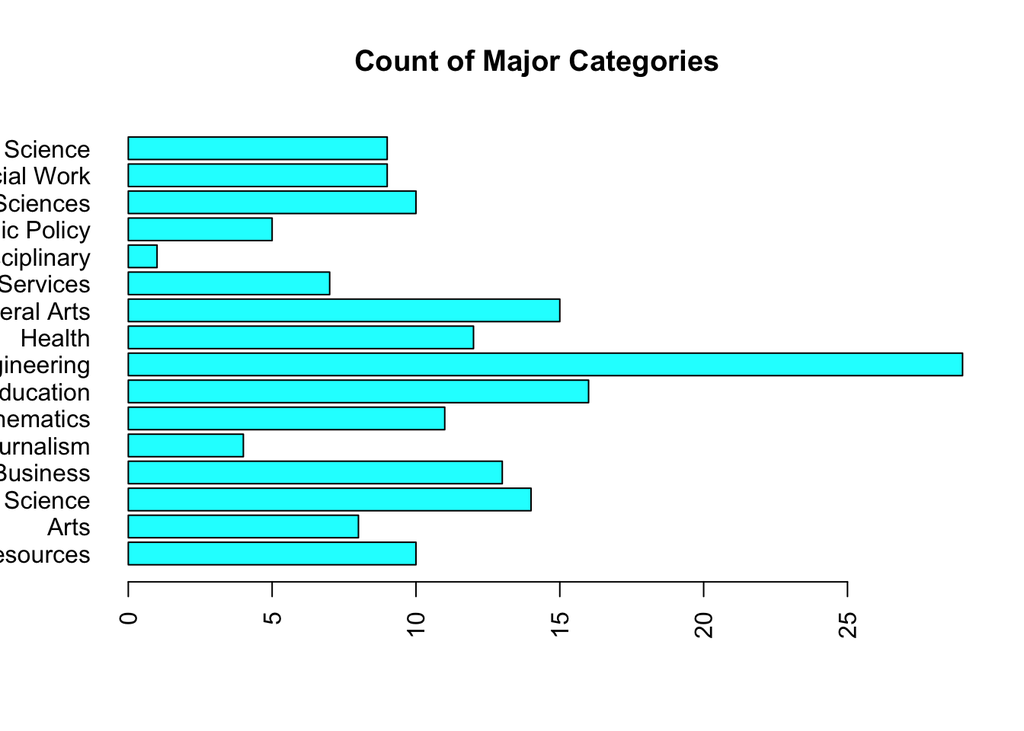

```r
par(las=2)
ct <- c(major_count$Count)
cou <-c(major_count$Category)
barplot(ct, names.arg = cou, main = "Count of Major Categories ", horiz = TRUE, col = "cyan")
```

# Write the fivethirtyeight data to a csv file. Make sure that it does not have row labels.

```r
write.csv(major_count, file = "Major Count.csv")
```